# DEM 7223 - Event History Analysis - Parametric Hazard Models

### Kaplan- Meier survival for second birth interval

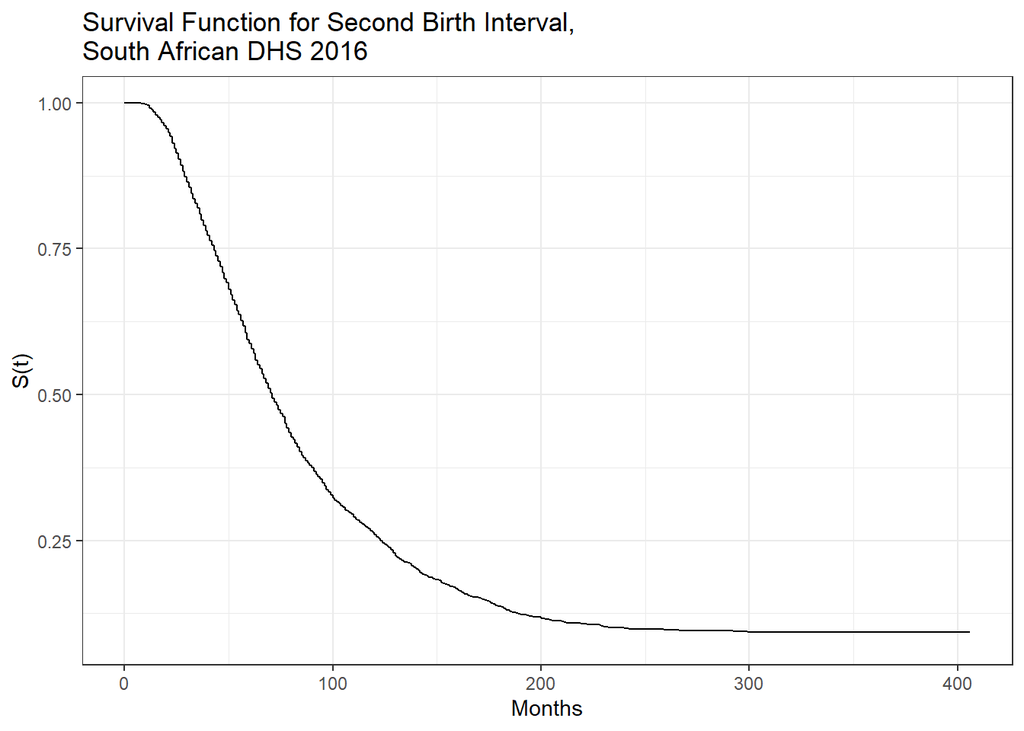

```r
library(ggsurvfit)
fit<-survfit2(Surv(secbi, b2event)~1, sub2)

fit %>%
  ggsurvfit()+
  labs(title = "Survival Function for Second Birth Interval,\nSouth African DHS 2016",
       y = "S(t)",
       x= "Months")
```

### Estimating Parametric Hazard Models

While parametric models are not so common in demographic research, fundamental understanding of what they are and how they are constructed is of importance.

Some outcomes lend themselves very readily to the parametric approach, but as many demographic duration times are non-unique (tied), the parametric models are not statistically efficient for estimating the survival/hazard functions, as they assume the survival times are continuous random variables.

In this section, we first estimate the empirical hazard function and then fit a variety of parametric models to it (Exponential, Weibull, Log-normal and Piecewise exponential). Ideally, a parametric model’s hazard function should approximate the observed empirical hazard function, *if the model fits the data*.

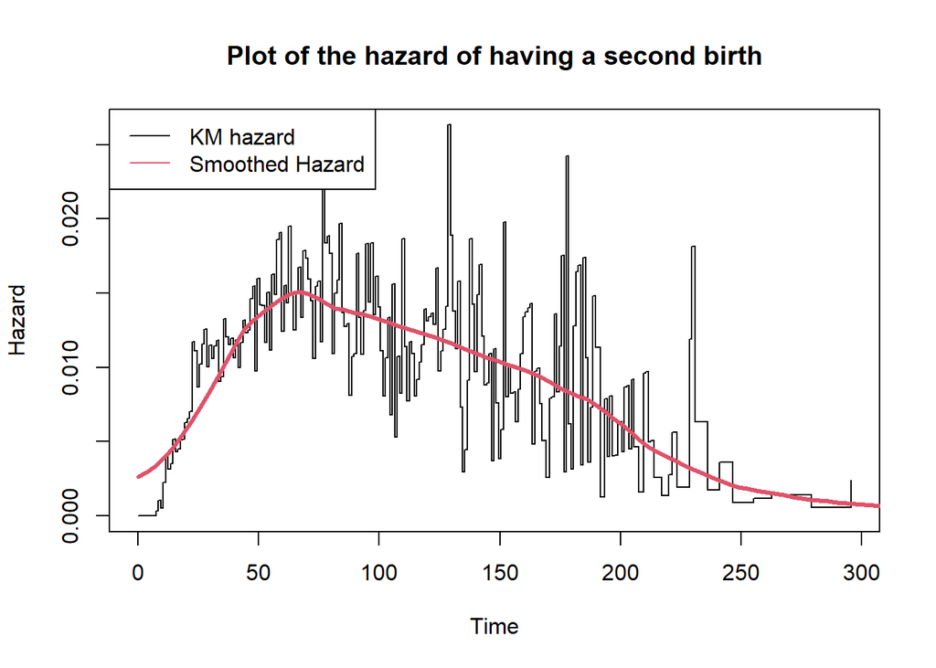

```r
#since these functions don't work with durations of 0, we add a very small amount to the intervals
fit.haz.km<-kphaz.fit(sub2$secbi,
                      sub2$b2event ,
                      method = "product-limit")

#this is a version of the hazard that is smoothed using a kernel-density method
fit.haz.sm<-muhaz(sub2$secbi, sub2$b2event )

#Empirical hazard function (product-limit estimate) plot
kphaz.plot(fit.haz.km,
           main="Plot of the hazard of having a second birth")

#overlay the smoothed version
lines(fit.haz.sm, col=2, lwd=3)
legend("topleft",
       legend = c("KM hazard", "Smoothed Hazard"),
       col=c(1,2),
       lty=c(1,1))
```

So now we see what the empirical hazard function looks like, in both the observed and smoothed estimate of it.

### Create covariates

Here, we create some predictor variables: Woman’s education (secondary +, vs < secondary), Woman’s age^2, Partner’s education (> secondary school)

```r
sub2$educ.high<-ifelse(sub2$educ %in% c(2,3), 1, 0)
sub2$age2<-(sub2$agefb)^2
sub2$partnerhiedu<-ifelse(sub2$partneredu<3,0,
                          ifelse(sub2$partneredu%in%c(8,9),NA,1 ))

options(survey.lonely.psu = "adjust")

des<-svydesign(ids=~psu, strata=~strata,
               data=sub2, weight=~weight )

#rep.des<-as.svrepdesign(des, type="bootstrap" )
```

# Fit the models

Now we fit the models.

I use the `eha` [package](http://cran.r-project.org/web/packages/eha/index.html) to do this, since it fits parametric proportional hazard models, not accelerated failure time models.

I prefer the interpretation of regression models on the hazard scale vs. the survival time scale. EHA is not the only package that will fit parametric survival models, be sure you *read the documentation for the procedure you use!!* Different functions fit different parameterizations of the distributions. For example, the `survreg()` function in the `survival` library fits accelerated failure time models only.

### Exponential Model

Often the exponential model isn’t directly available in packages, so we can fit a weibull model with a fixed shape parameter. This is 100% legal.

The exponential distribution has a constant hazard rate, $\lambda (t) = \lambda$. The survival function is $S(t) = \exp (-\lambda t)$

To specify the model in terms of covariates, you can write the hazard as a log-linear model : $\text{log} \lambda = x`\beta$

```r
#exponential distribution for hazard, here we hard code it to be
#a weibull dist with shape ==1

day<- 1/365

sub2 <- sub2 %>%
  filter( is.na(partnerhiedu) == F)

fit.1<-phreg(Surv(secbi+day, b2event)~educ.high+partnerhiedu+agec,
             data=sub2,
             dist="weibull",
             shape = 1)

summary(fit.1)
```

```
Covariate             Mean       Coef     Rel.Risk   S.E.    LR p
educ.high             0.843    -0.132     0.877     0.062   0.0371
partnerhiedu          0.121    -0.010     0.990     0.070   0.8831
agec                                                        0.0013
         [15,20]      0.004     0         1 (reference)
         (20,25]      0.049     0.338     1.402     0.421
         (25,30]      0.134     0.552     1.737     0.412
         (30,35]      0.227     0.420     1.522     0.411
         (35,40]      0.205     0.350     1.419     0.411
         (40,45]      0.206     0.274     1.315     0.412
         (45,50]      0.174     0.222     1.249     0.412

Events                    1980
Total time at risk        181366
Max. log. likelihood      -10913
LR test statistic         23.57
Degrees of freedom        8
Overall p-value           0.00270285
```

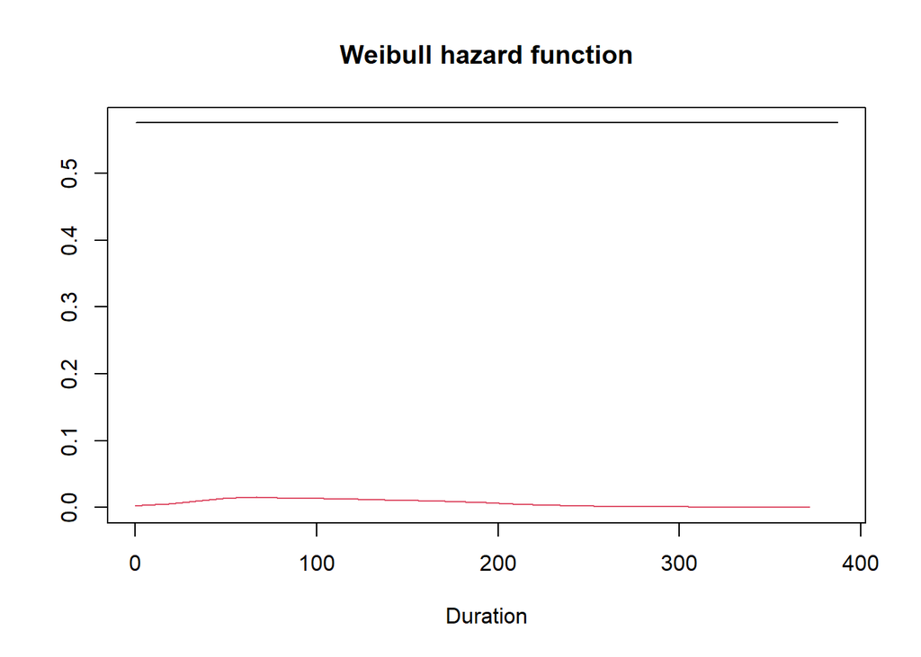

```r
plot(fit.1)
lines(fit.haz.sm, col=2)
```

###Interpreting the model coefficients To interpret the effects specifically, you can use the `Exp(Coef)` column. So, for example for women who have secondary or higher education, their hazard of having a second child is 12.333 lower than a woman with less than a secondary education. To get that number I do : $100* 1 - \exp(\beta_{\text{educ.high }})$

$\text{Hazard Ratio} = \frac{\exp \left( \beta_{\text{I(age/5)}} * 7 + \beta_{\text{age2}}*7 \right )}{\exp \left( \beta_{\text{I(age/5)}} * 4 + \beta_{\text{age2}}*4 \right )}$

I choose 7 because `7 * 5` = 35, and 4 because `4*5` = 20. Remember, I divided Age by 5 when I created my variables.

### AFT model specification

If you wanted to do the AFT model, you can either `aftreg()` in the `eha` package or `survreg()` in the `survival` package. Generally AFT models are written as:

$\text{log} T = -x ` \beta + \sigma W$ Where *W* is an error (residual) term, which is assumed to follow some distribution.

```r
fit.1.aft<-survreg(Surv(secbi+day, b2event)~educ.high+partnerhiedu+agec,
                   data=sub2,
                   dist = "exponential" )

summary(fit.1.aft)
```

```
Call:
survreg(formula = Surv(secbi + day, b2event) ~ educ.high + partnerhiedu +
    agec, data = sub2, dist = "exponential")
               Value Std. Error     z      p
(Intercept)   4.7641     0.4110 11.59 <2e-16
educ.high     0.1316     0.0623  2.11  0.035
partnerhiedu  0.0103     0.0704  0.15  0.883
agec(20,25]  -0.3377     0.4212 -0.80  0.423
agec(25,30]  -0.5523     0.4123 -1.34  0.180
agec(30,35]  -0.4198     0.4110 -1.02  0.307
agec(35,40]  -0.3502     0.4114 -0.85  0.395
agec(40,45]  -0.2742     0.4116 -0.67  0.505
agec(45,50]  -0.2222     0.4123 -0.54  0.590

Scale fixed at 1

Exponential distribution
Loglik(model)= -10912.7   Loglik(intercept only)= -10924.5
    Chisq= 23.57 on 8 degrees of freedom, p= 0.0027
Number of Newton-Raphson Iterations: 5
n= 2492
```

Which shows, compared to the PH model, that the coefficients are all backwards. That’s because if a predictor lowers the hazard, then, by default it extends survival.

### Lower risk == longer survival times!

## Plotting the survival curves

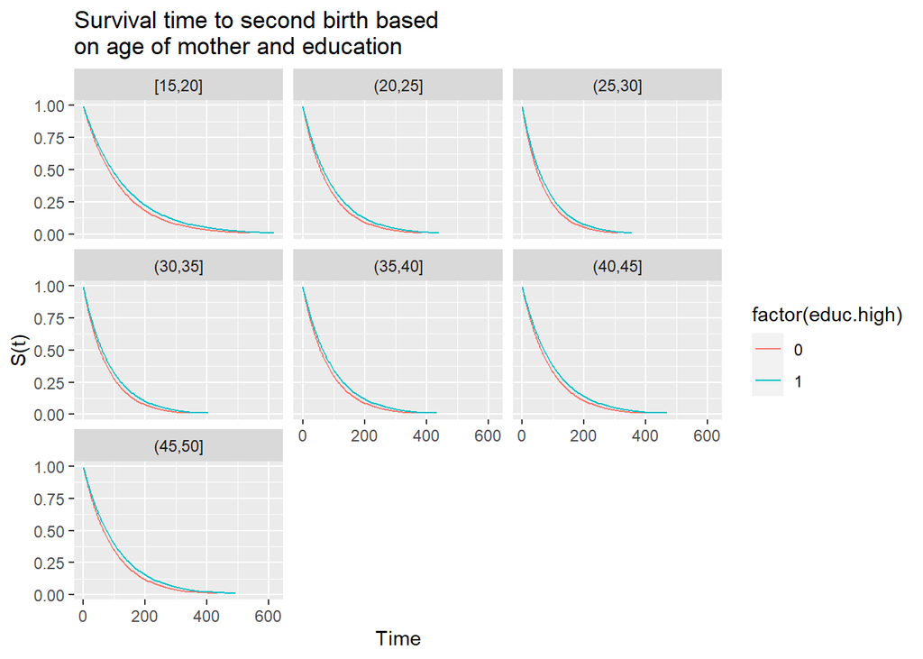

```r
newdat <- expand.grid(educ.high = c(0,1),
                      partnerhiedu = mean(sub2$partnerhiedu),
                      agec = levels(sub2$agec))

#percentiles of the survival function
percs <- (1:99)/100

fitted <- as.data.frame(predict(fit.1.aft,
                  newdata=newdat,
                  type="quantile",
                  p=percs,
                  se=F))

names(fitted) <- paste("surv", 1:99, sep = "_")

newdat2 <- cbind(newdat, fitted)

#reshape the data
out<-newdat2 %>%
  #as.data.frame()%>%
  select(-partnerhiedu)%>%
  pivot_longer(cols = c(-educ.high, -agec),
               names_to  = c(".value", "time"),
               names_sep = "_")

out$p <- rep(1-percs, 14)

out %>%
  ggplot()+
  aes(y=p, x = surv,
      color=factor(educ.high),
      group=educ.high) +
  geom_line() +
  facet_wrap(~agec)+
  labs(x="Time", y="S(t)",
       title = "Survival time to second birth based\non age of mother and education")
```

### Weibull Model

The Weibull model is more flexible than the Exponential, because it’s distribution function has two parameters, scale and shape.

The Weibull distribution has hazard rate, $\lambda(t)=\lambda^p p t^{p-1}$. Where $\lambda$ is the scale and *p* is the shape. The survival function is $S(t) = exp ( -(\lambda t)^p)$

```r
#weibull distribution for hazard
fit.2<-phreg(Surv(secbi+day, b2event)~educ.high+partnerhiedu+agec,
             data=sub2,
             dist="weibull")
summary(fit.2)
```

```
Covariate             Mean       Coef     Rel.Risk   S.E.    LR p
educ.high             0.843    -0.137     0.872     0.062   0.0300
partnerhiedu          0.121     0.009     1.009     0.070   0.8954
agec                                                        0.0000
         [15,20]      0.004     0         1 (reference)
         (20,25]      0.049     0.088     1.092     0.421
         (25,30]      0.134     0.151     1.163     0.413
         (30,35]      0.227    -0.090     0.914     0.412
         (35,40]      0.205    -0.246     0.782     0.413
         (40,45]      0.206    -0.402     0.669     0.413
         (45,50]      0.174    -0.493     0.611     0.414

Events                    1980
Total time at risk        181366
Max. log. likelihood      -10715
LR test statistic         82.90
Degrees of freedom        8
Overall p-value           1.27676e-14
```

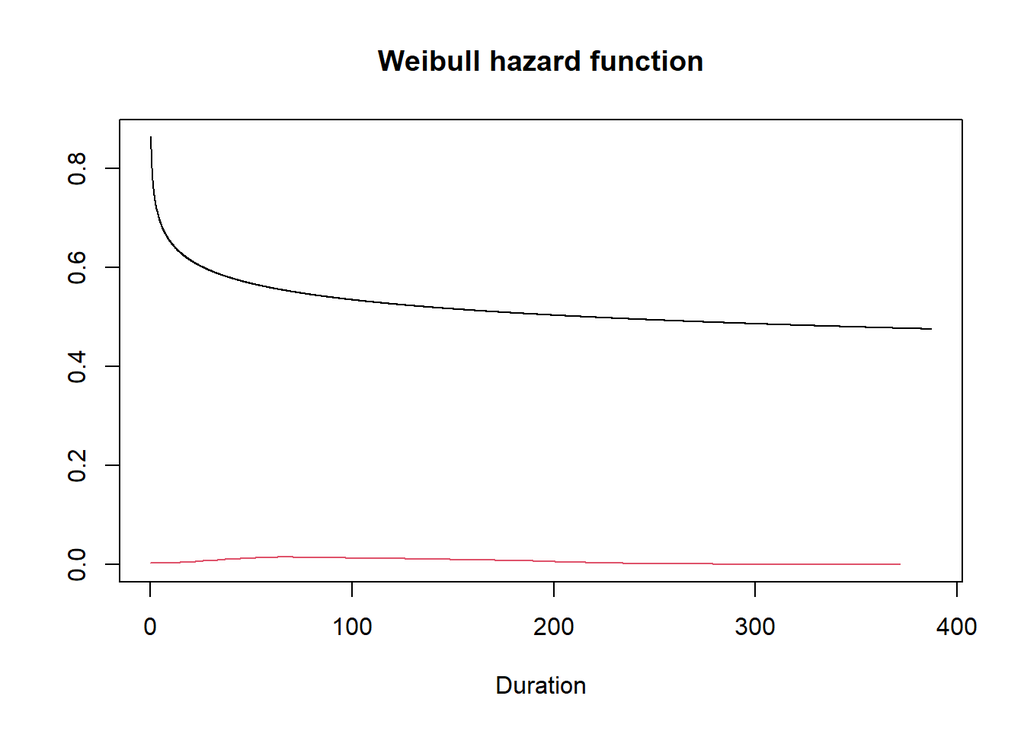

```r
plot(fit.2, fn = "haz")
lines(fit.haz.sm, col=2)
```

##Note on exponential and Weibull models AFT vs PH parameterization and, as a nice trick for the exponential and weibull models, you can rescale the AFT beta’s to PH model betas (see [here](http://www.statisticsmentor.com/2012/12/25/r-relationship-between-accelerated-failure-model-and-the-proportional-hazard-model-for-weibull/))

```r
#re-scaled beta's
(betaHat <- -coef(fit.1.aft)[-1] / fit.1.aft$scale)
```

```
   educ.high partnerhiedu  agec(20,25]  agec(25,30]  agec(30,35]  agec(35,40]
 -0.13162131  -0.01033307   0.33770807   0.55230485   0.41981875   0.35020624
 agec(40,45]  agec(45,50]
  0.27419650   0.22222686
```

```r
#beta's from the PH model
coef(fit.1)
```

```
   educ.high partnerhiedu  agec(20,25]  agec(25,30]  agec(30,35]  agec(35,40]
 -0.13162131  -0.01033307   0.33770807   0.55230485   0.41981875   0.35020624
 agec(40,45]  agec(45,50]   log(scale)
  0.27419650   0.22222686   4.76411157
```

So for these two models, you can go back and forth.

### Log-Normal Model

The Log-normal distribution is more flexible and allows the hazard to change direction.

The Log-normal distribution has hazard rate,

$$h(t) = \frac{\phi \left (\frac{log t}{\sigma} \right ) }{\left [ 1 - \Phi \left ( \frac{log t}{\sigma} \right ) \right ] \sigma t}$$

Where $\sigma$ is the shape.

The survival function is $S(t) = 1 - \Phi \left ( \frac{log t - \mu}{\sigma} \right )$

```r
#log-normal distribution for hazard
fit.3<-phreg(Surv(secbi, b2event)~educ.high+partnerhiedu+agec,
             data=sub2,
             dist="lognormal")

summary(fit.3)
```

```
Covariate             Mean       Coef     Rel.Risk   S.E.    LR p
educ.high             0.843    -0.857     0.424     0.490   0.0068
partnerhiedu          0.121    -0.172     0.842     0.062   0.8643
agec                                                        0.0000
         [15,20]      0.004     0         1 (reference)
         (20,25]      0.049     0.012     1.012     0.070
         (25,30]      0.134    -0.165     0.848     0.421
         (30,35]      0.227    -0.124     0.883     0.413
         (35,40]      0.205    -0.349     0.706     0.412
         (40,45]      0.206    -0.441     0.644     0.413
         (45,50]      0.174    -0.514     0.598     0.413

Events                    1980
Total time at risk        181359
Max. log. likelihood      -10471
LR test statistic         44.41
Degrees of freedom        8
Overall p-value           4.75121e-07
```

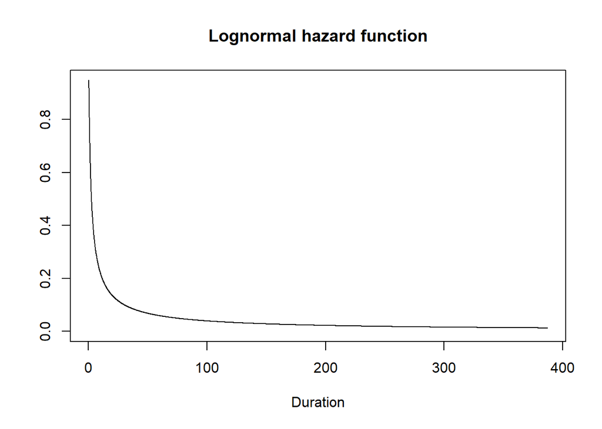

```r
plot(fit.3)
```

```r
#plot the hazard from the log normal vs the empirical hazard
#plot(fit.3)
#lines(fit.haz.sm, col=2)
```

**Log-logistic Model**

**NOTE** This one may be unstable as well

```r
#log-normal distribution for hazard
fit.4<-phreg(Surv(secbi, b2event)~educ.high+partnerhiedu,
             data=sub2,
             dist="loglogistic")
summary(fit.4)
```

```
Covariate             Mean       Coef     Rel.Risk   S.E.    LR p
educ.high             0.843    -0.492     0.611     0.091   0.0566
partnerhiedu          0.121    -0.118     0.889     0.061   0.9493

Events                    1980
Total time at risk        181359
Max. log. likelihood      -10485
LR test statistic         3.68
Degrees of freedom        2
Overall p-value           0.158704
```

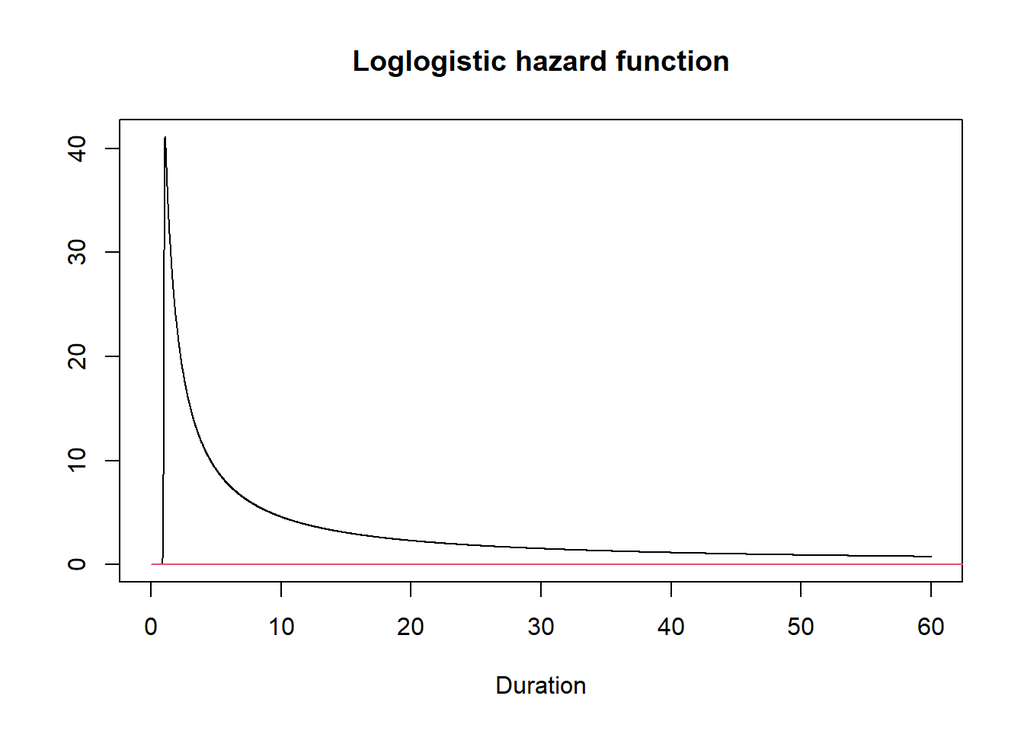

```r
#plot the hazard from the log normal vs the empirical hazard
plot(fit.4, fn="haz", xlim = c(0, 60))
lines(fit.haz.sm, col=2)
```

Whose hazard function drops off faster than the log-normal.

We may want to compare the models to one another based off AIC values. the `eha` package doesn’t give this to you, so we must calculate it:

```r
AIC(fit.1)
```

```
[1] 21843.41
```

```r
AIC(fit.2)
```

```
[1] 21449.63
```

```r
AIC(fit.3)
```

```
[1] 20964.05
```

```r
AIC(fit.4)
```

```
[1] 20979.86
```

### Piecewise constant exponential model

The final model we consider is the Piecewise constant exponential model. This model breaks the data into pieces, where we may fit constant hazards within these pieces.

```r
# here I must supply the times for the "pieces" where I expect the  hazard to be constant
fit.5<-pchreg(Surv(secbi, b2event)~educ.high+partnerhiedu,
             data=sub2,
             cuts=seq(1, 300, 12))
summary(fit.5)
```

```
Covariate             Mean       Coef     Rel.Risk   S.E.    LR p
educ.high             0.843    -0.128     0.880     0.061   0.0384
partnerhiedu          0.121     0.009     1.009     0.070   0.8969

Events                    1980
Total time at risk        181359
Max. log. likelihood      -10481
LR test statistic         4.32
Degrees of freedom        2
Overall p-value           0.115586

Restricted mean survival:  78.1798 in (1, 289]
```

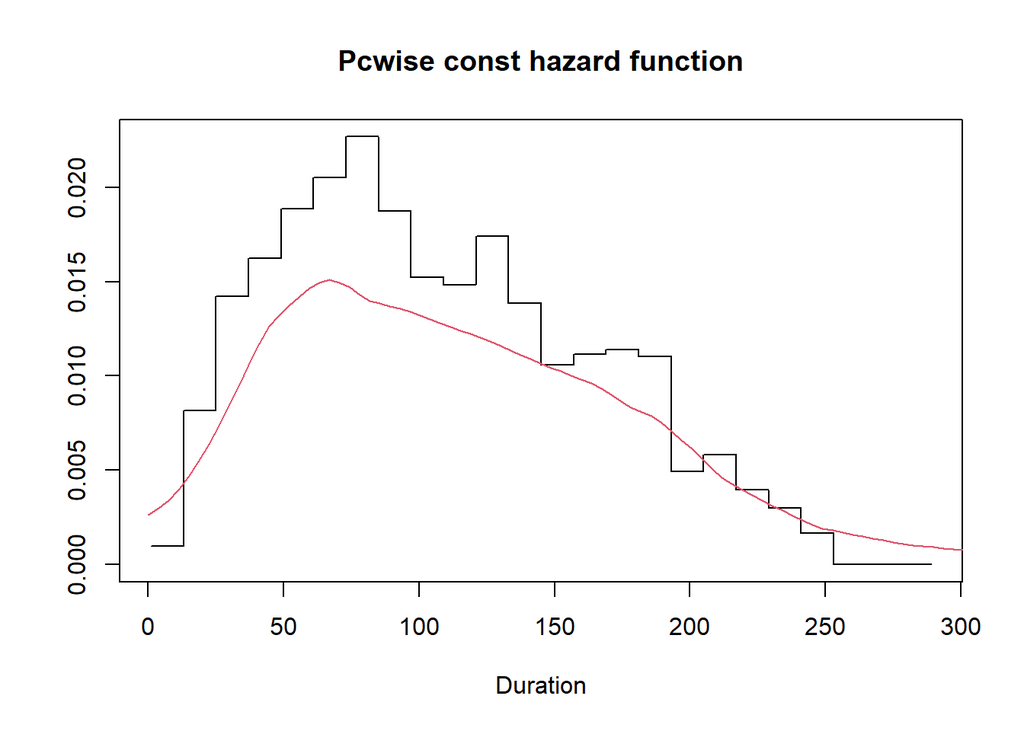

```r
plot(fit.5, fn="haz")
lines(fit.haz.sm, col=2)
```

```r
AIC(fit.4)
```

```
[1] 20979.86
```

```r
-2*fit.5$loglik[2]+length(fit.5$coefficients) #have to construct this ourselves
```

```
[1] 20964.66
```

## Graphical checks on the model fit

The `eha` package also provides a graphical method for the Cumulative hazard function, which allows us to visualize these models even better. It uses the empirical hazard, as fit in the Cox model (more on this next week), and compares the parametric models to the empirical pattern:

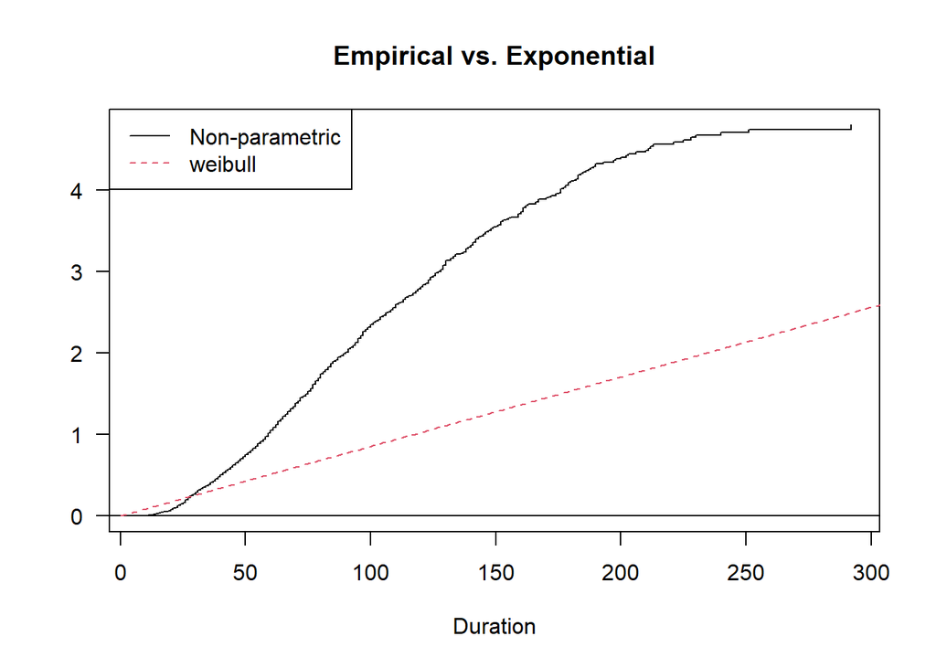

```r
emp<-coxreg(Surv(secbi, b2event)~educ.high+partnerhiedu+agec,
            data=sub2)

check.dist(sp=emp,pp=fit.1, main = "Empirical vs. Exponential")
```

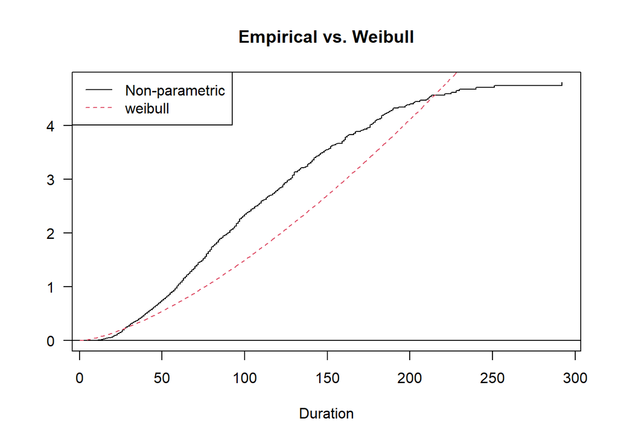

```r
check.dist(sp=emp,pp=fit.2, main = "Empirical vs. Weibull")
```

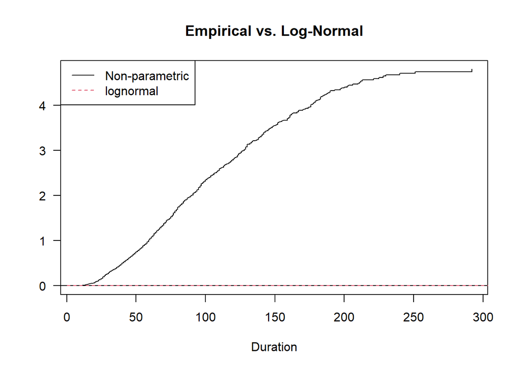

```r
check.dist(sp=emp,pp=fit.3, main = "Empirical vs. Log-Normal")
```